# Portfolio: Part 3

John Higdon

12/9/2019

Before we begin, let’s pull in the work from the previous two projects.

```r
suppressWarnings(suppressMessages(library("knitr")))
suppressWarnings(suppressMessages(purl("p2.Rmd", output = "p2.r")))
```

```
## [1] "p2.R"
```

```r
suppressWarnings(suppressMessages(source("p2.r")))
```

To recap, we will display a snippet of tables we have tidied and prepared for analysis in the last two phases of the project

```r
head(avg_gdpAndPersonalIncomeByState)
```

```
##      GeoName    avg_gdp avg_income
## 1    Alabama  27242.725   41570.67
## 2     Alaska   6249.929   58422.67
## 3    Arizona  41853.691   43639.89
## 4   Arkansas  15936.127   42564.00
## 5 California 362504.553   62259.44
## 6   Colorado  44289.589   57272.11
```

```r
head(avg_gdpAndPersonalIncomeByRegion)
```

```
##          GeoName   avg_gdp avg_income
## 1       Far West 496815.99   60140.89
## 2    Great Lakes 349086.49   50096.44
## 3        Mideast 562800.35   63373.78
## 4    New England 150485.95   66623.89
## 5         Plains 157871.79   51163.78
## 6 Rocky Mountain  96661.97   51358.44
```

Now that we’ve explored a few models, let’s utilize the idea of cross-validation. We will split our dataset into training and testing datasets and will determine if any of the variables we have been exploring can realistically be used to predict outcomes.

We will split the average GDP and personal income by state dataset into 75% training and 25% test.

For the regional dataset, we will split the dataset 50/50 into training testing because there aren’t many observations.

```r
suppressWarnings(suppressMessages(library("caret")))

# Generate training and testing datasets for variables of interest regarding state and regional data.

# state
simple_selection <- createDataPartition(avg_gdpAndPersonalIncomeByState$avg_gdp, p = 0.75, list = FALSE)
train_state <- avg_gdpAndPersonalIncomeByState[simple_selection, ]
test_state <- avg_gdpAndPersonalIncomeByState[-simple_selection, ]

# regional
simple_selection_reg <- createDataPartition(avg_gdpAndPersonalIncomeByRegion$avg_gdp, p = 0.5, list = FALSE)
train_region <- avg_gdpAndPersonalIncomeByRegion[simple_selection_reg, ]
test_region <- avg_gdpAndPersonalIncomeByRegion[-simple_selection_reg, ]
```

Now that we’ve split our data into training and testing datasets, we can build linear regression models based on the training sets we previously created. Let’s determine if avg_gdp or avg_income can be predicted by any variables we tested.

```r
# state models
model_gdpState <- lm(avg_gdp ~ avg_income, data = train_state)
model_incomeState <- lm(avg_income ~ avg_gdp, data = train_state)

# regional models
model_gdpRegion <- lm(avg_gdp ~ avg_income, data = train_region)
model_incomeRegion <- lm(avg_income ~ avg_gdp, data = train_region)
```

We’re now ready to begin our prediction process. Let’s view a summary of each linear model, then calculate the R^2, RMSE and MAE values (sourced from: http://www.sthda.com/english/articles/38-regression-model-validation/157-cross-validation-essentials-in-r/#model-performance-metrics)

```r
# summarize the models
summary(model_gdpState)
```

```
##
## Call:
## lm(formula = avg_gdp ~ avg_income, data = train_state)
##
## Residuals:
##    Min     1Q Median     3Q    Max
## -89134 -36058 -17797   5474 290787
##
## Coefficients:
##               Estimate Std. Error t value Pr(>|t|)
## (Intercept) -48505.013  62772.071  -0.773    0.445
## avg_income       1.931      1.176   1.642    0.109
##
## Residual standard error: 69040 on 37 degrees of freedom
## Multiple R-squared:  0.06789,    Adjusted R-squared:  0.0427
## F-statistic: 2.695 on 1 and 37 DF,  p-value: 0.1091
```

```r
summary(model_incomeState)
```

```
##
## Call:
## lm(formula = avg_income ~ avg_gdp, data = train_state)
##
## Residuals:
##    Min     1Q Median     3Q    Max
## -13869  -6050  -1463   3717  29502
##
## Coefficients:
##              Estimate Std. Error t value Pr(>|t|)
## (Intercept) 5.067e+04  1.874e+03  27.044   <2e-16 ***
## avg_gdp     3.516e-02  2.142e-02   1.642    0.109
## ---
## Signif. codes:  0 '***' 0.001 '**' 0.01 '*' 0.05 '.' 0.1 ' ' 1
##
## Residual standard error: 9316 on 37 degrees of freedom
## Multiple R-squared:  0.06789,    Adjusted R-squared:  0.0427
## F-statistic: 2.695 on 1 and 37 DF,  p-value: 0.1091
```

```r
summary(model_gdpRegion)
```

```
##
## Call:
## lm(formula = avg_gdp ~ avg_income, data = train_region)
##
## Residuals:
##       1       5       6       7
##  129486 -155343 -217727  243584
##
## Coefficients:
##              Estimate Std. Error t value Pr(>|t|)
## (Intercept) 4.795e+03  1.453e+06   0.003    0.998
## avg_income  6.028e+00  2.765e+01   0.218    0.848
##
## Residual standard error: 271700 on 2 degrees of freedom
## Multiple R-squared:  0.02321,    Adjusted R-squared:  -0.4652
## F-statistic: 0.04752 on 1 and 2 DF,  p-value: 0.8477
```

```r
summary(model_incomeRegion)
```

```
##
## Call:
## lm(formula = avg_income ~ avg_gdp, data = train_region)
##
## Residuals:
##        1        5        6        7
##  7153.32  -518.76   -88.42 -6546.13
##
## Coefficients:
##              Estimate Std. Error t value Pr(>|t|)
## (Intercept) 5.107e+04  6.615e+03   7.722   0.0164 *
## avg_gdp     3.850e-03  1.766e-02   0.218   0.8477
## ---
## Signif. codes:  0 '***' 0.001 '**' 0.01 '*' 0.05 '.' 0.1 ' ' 1
##
## Residual standard error: 6867 on 2 degrees of freedom
## Multiple R-squared:  0.02321,    Adjusted R-squared:  -0.4652
## F-statistic: 0.04752 on 1 and 2 DF,  p-value: 0.8477
```

```r
set.seed(111)

# Calculate mean squared difference between the observed and the predicted outcome values.
# The one that produces the lowest RMSE value is the preffered model when comparing between models.

# gdp by state
predictions_gdpState <- model_gdpState %>% predict(test_state)
data.frame( R2 = R2(predictions_gdpState, test_state$avg_gdp),
            RMSE = RMSE(predictions_gdpState, test_state$avg_gdp),
            MAE = MAE(predictions_gdpState, test_state$avg_gdp))
```

```
##          R2     RMSE      MAE
## 1 0.0256951 30595.93 24618.46
```

```r
prediction_error_rate_gdpState <- RMSE(predictions_gdpState, test_state$avg_gdp)/mean(test_state$avg_gdp)
prediction_error_rate_gdpState
```

```
## [1] 0.8414096
```

```r
# income by state
predictions_incomeState <- model_incomeState %>% predict(test_state)
data.frame( R2 = R2(predictions_incomeState, test_state$avg_income),
            RMSE = RMSE(predictions_incomeState, test_state$avg_income),
            MAE = MAE(predictions_incomeState, test_state$avg_income))
```

```
##          R2    RMSE      MAE
## 1 0.0256951 7507.61 6569.695
```

```r
prediction_error_rate_incomeState <- RMSE(predictions_incomeState, test_state$avg_income)/mean(test_state$avg_income)
prediction_error_rate_incomeState
```

```
## [1] 0.1489424
```

```r
# gdp by region
predictions_gdpRegion <- model_gdpRegion %>% predict(test_region)
data.frame( R2 = R2(predictions_gdpRegion, test_region$avg_gdp),
            RMSE = RMSE(predictions_gdpRegion, test_region$avg_gdp),
            MAE = MAE(predictions_gdpRegion, test_region$avg_gdp))
```

```
##             R2     RMSE      MAE
## 1 7.150443e-05 156736.4 119285.4
```

```r
prediction_error_rate_gdpRegion <- RMSE(predictions_gdpRegion, test_region$avg_gdp)/mean(test_region$avg_gdp)
prediction_error_rate_gdpRegion
```

```
## [1] 0.4619861
```

```r
# income by region
predictions_incomeRegion <- model_gdpRegion %>% predict(test_region)
data.frame( R2 = R2(predictions_incomeRegion, test_region$avg_income),
            RMSE = RMSE(predictions_incomeRegion, test_region$avg_income),
            MAE = MAE(predictions_incomeRegion, test_region$avg_income))
```

```
##   R2     RMSE      MAE
## 1  1 293926.5 291018.3
```

```r
prediction_error_rate_incomeRegion <- RMSE(predictions_incomeRegion, test_region$avg_income)/mean(test_region$avg_income)
prediction_error_rate_incomeRegion
```

```
## [1] 5.163416
```

### Discussion of Results

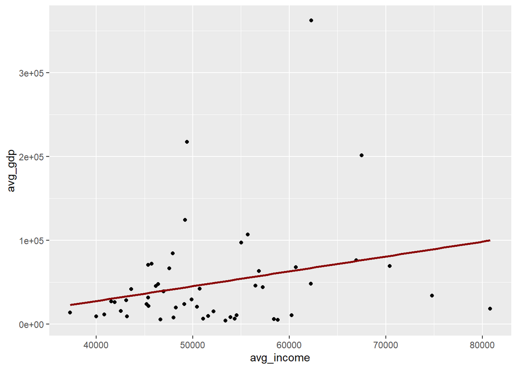

```r
ggplot(avg_gdpAndPersonalIncomeByState, aes(x = avg_income, y = avg_gdp)) + geom_point() + geom_smooth(method=lm, se=FALSE, color="darkred")
```

What I found interesting, while not necessarily useful for predictive models, were the results discovered after the operations done in part 2 where we have clean and tidy tables that show the average gdp and personal income of each state and region.

The top three states for average gdp are:

1. California
2. Texas
3. New York

Top three states for average personal income:

1. District of Columbia
2. Connecticut
3. Massachusetts

Regional gdp:

1. Mideast
2. Southeast
3. Far West

Regional personal income:

1. New England
2. Mideast
3. Far West

### Operationalization & Social Impact

To automate the data collection, we could potentially develop a web scaraping utility that updates ours tables periodically.

A very naive way to operationalize this model would be to increase minimum wage substantially and evaluate if GDP is affected. Other factors worth investigating would be number of hours worked vs average personal income to see if either can be used to predict the “happiness” or “well-being” of an individual in further studies.

Unintended consequences of such an action could be the increse of costs for basic goods and services that further limits access to resources for the working class and lower. Companies may lay off more workers or move their operations to other locations/countries, displacing workers in the process.